**POLS/CSSS 503, University of Washington, Spring 2015**

# Lab 6 - More Regression Interpretation

Carolina Johnson, Jeffrey B. Arnold

Friday May 8, 2015

As always, start the lab by loading the packages we will be using.

```r
library("car")
library("lmtest")
library("MASS")
library("dplyr")
library("ggplot2")
library("broom")
```

## More on Interpretation

Once more we’ll use data from Ross on oil, this time from the earlier 2001 paper.

```r
rossdata_url <- "http://staff.washington.edu/csjohns/503/rossoildata.csv"
rossdata_raw <- read.csv(rossdata_url, stringsAsFactors = FALSE)
rossdata <- rossdata_raw %>% select(cty_name, year, regime1,
  oil, GDPcap, oecd) %>% na.omit()
```

```r
model1 <- lm(regime1 ~ GDPcap + oil + oecd + year, data = rossdata)
summary(model1)
```

```
##
## Call:
## lm(formula = regime1 ~ GDPcap + oil + oecd + year, data = rossdata)
##
## Residuals:
##     Min      1Q  Median      3Q     Max
## -7.8284 -2.5065 -0.2086  2.2014  8.0464
##
## Coefficients:
##               Estimate Std. Error t value Pr(>|t|)
## (Intercept) -1.736e+02  1.664e+01 -10.433  < 2e-16 ***
## GDPcap       6.177e-05  1.823e-05   3.387 0.000716 ***
## oil         -8.262e-02  5.022e-03 -16.450  < 2e-16 ***
## oecd         4.116e+00  1.928e-01  21.346  < 2e-16 ***
## year         9.008e-02  8.413e-03  10.708  < 2e-16 ***
## ---
## Signif. codes:  0 '***' 0.001 '**' 0.01 '*' 0.05 '.' 0.1 ' ' 1
##
## Residual standard error: 2.932 on 2589 degrees of freedom
## Multiple R-squared:  0.4285, Adjusted R-squared:  0.4276
## F-statistic: 485.2 on 4 and 2589 DF,  p-value: < 2.2e-16
```

Now predict the expected value of regime type vs. oil:

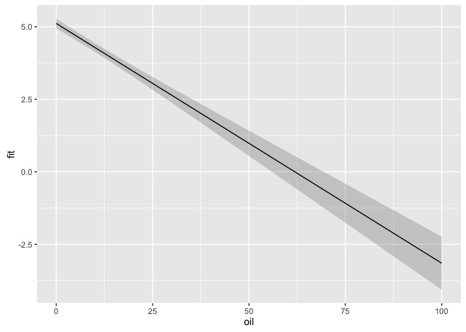

```r
pred1_df <- data.frame(oil = seq(0, 100, by = 10), GDPcap = mean(rossdata$GDPcap),
  oecd = 0, year = median(rossdata$year))
pred1 <- predict(model1, newdata = pred1_df, interval = "confidence")

ggplot(bind_cols(pred1_df, as.data.frame(pred1)), aes(x = oil,
  y = fit, ymin = lwr, ymax = upr)) + geom_ribbon(alpha = 0.2) +
  geom_line()
```

This is easiest to plot with `augment` instead

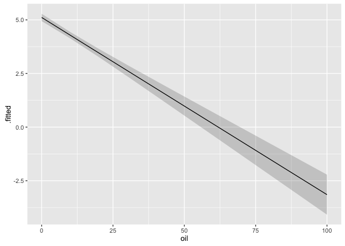

```r
pred1_aug <- augment(model1, newdata = pred1_df)
ggplot(pred1_aug, aes(x = oil, y = .fitted, ymin = .fitted +
  2 * .se.fit, ymax = .fitted - 2 * .se.fit)) + geom_ribbon(alpha = 0.2) +
  geom_line()
```

**Challenge:** Do this with both OECD and non-OECD countries. Before plotting, how will these differ?

**Answer:**

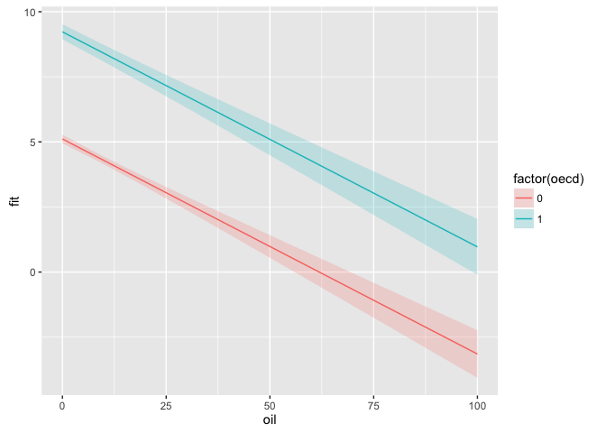

```r
pred2_df <- expand.grid(oil = seq(0, 100, by = 10), GDPcap = mean(rossdata$GDPcap),
  oecd = c(0, 1), year = median(rossdata$year))
pred2 <- predict(model1, newdata = pred2_df, interval = "confidence")
ggplot(bind_cols(pred2_df, as.data.frame(pred2)), aes(x = oil,
  y = fit, ymin = lwr, ymax = upr, colour = factor(oecd), fill = factor(oecd))) +
  geom_ribbon(alpha = 0.2, colour = NA) + geom_line()
```

This is easiest to plot with `augment` instead

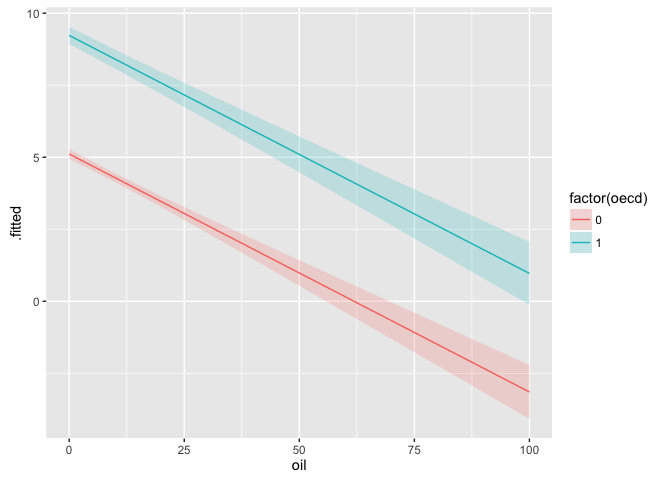

```r
pred1_aug <- augment(model1, newdata = pred2_df)
ggplot(pred1_aug, aes(x = oil, y = .fitted, ymin = .fitted +
  2 * .se.fit, ymax = .fitted - 2 * .se.fit, fill = factor(oecd),
  colour = factor(oecd))) + geom_ribbon(alpha = 0.2, colour = NA) +
  geom_line()
```

**Challenge:** Does it make sense to plot `oil` from 0 to 100? Check the range of `oil`.

**Answer:** Surprisingly, not that bad.

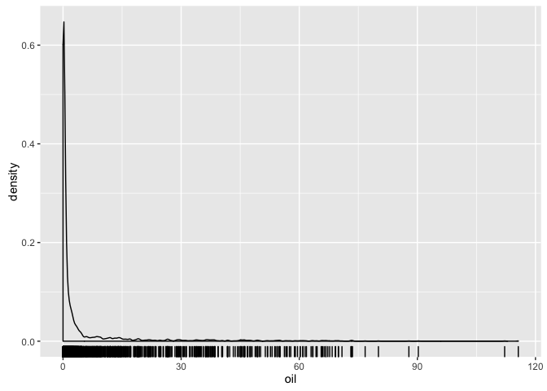

```r
ggplot(rossdata, aes(x = oil)) + geom_density() + geom_rug()
```

**Challenge:** Interact `oil` with `oecd` and plot. What will the lines look like?

```r
model2 <- lm(regime1 ~ GDPcap + oil * oecd + year, data = rossdata)
summary(model2)
```

```
##
## Call:
## lm(formula = regime1 ~ GDPcap + oil * oecd + year, data = rossdata)
##
## Residuals:
##     Min      1Q  Median      3Q     Max
## -7.7411 -2.5075 -0.1755  2.2446  8.0701
##
## Coefficients:
##               Estimate Std. Error t value Pr(>|t|)
## (Intercept) -1.732e+02  1.663e+01 -10.410  < 2e-16 ***
## GDPcap       5.931e-05  1.826e-05   3.248  0.00118 **
## oil         -8.344e-02  5.035e-03 -16.571  < 2e-16 ***
## oecd         4.005e+00  2.003e-01  19.998  < 2e-16 ***
## year         8.985e-02  8.408e-03  10.686  < 2e-16 ***
## oil:oecd     8.863e-02  4.340e-02   2.042  0.04124 *
## ---
## Signif. codes:  0 '***' 0.001 '**' 0.01 '*' 0.05 '.' 0.1 ' ' 1
##
## Residual standard error: 2.93 on 2588 degrees of freedom
## Multiple R-squared:  0.4294, Adjusted R-squared:  0.4283
## F-statistic: 389.5 on 5 and 2588 DF,  p-value: < 2.2e-16
```

Now consider interact `oil` with `year`. How would you plot two continuous variables?

```r
model3 <- lm(regime1 ~ GDPcap + oecd + oil * year, data = rossdata)
summary(model3)
```

```
##
## Call:
## lm(formula = regime1 ~ GDPcap + oecd + oil * year, data = rossdata)
##
## Residuals:
##     Min      1Q  Median      3Q     Max
## -7.7659 -2.4662 -0.2211  2.2458  7.5283
##
## Coefficients:
##               Estimate Std. Error t value Pr(>|t|)
## (Intercept) -1.900e+02  1.721e+01 -11.039  < 2e-16 ***
## GDPcap       6.228e-05  1.819e-05   3.424 0.000628 ***
## oecd         4.108e+00  1.924e-01  21.351  < 2e-16 ***
## oil          4.400e+00  1.242e+00   3.543 0.000403 ***
## year         9.835e-02  8.700e-03  11.304  < 2e-16 ***
## oil:year    -2.263e-03  6.269e-04  -3.609 0.000313 ***
## ---
## Signif. codes:  0 '***' 0.001 '**' 0.01 '*' 0.05 '.' 0.1 ' ' 1
##
## Residual standard error: 2.925 on 2588 degrees of freedom
## Multiple R-squared:  0.4313, Adjusted R-squared:  0.4302
## F-statistic: 392.6 on 5 and 2588 DF,  p-value: < 2.2e-16
```

In order to interpret the interaction term graphically, we need to pick one variable to treat as continuous — the x-axis — and another for which we will choose specific values. Use `oil` as the x-axis, and some values of `year` at which to evaluate it. For `year` we could use the min, max, and median.

```r
pred3_newdata <- expand.grid(oecd = 0, GDPcap = mean(rossdata$GDPcap),
  year = c(1966, 1981, 1997), oil = seq(0, 100, by = 10))
pred3 <- augment(model3, newdata = pred3_newdata)
```

Now, let’s plot it,

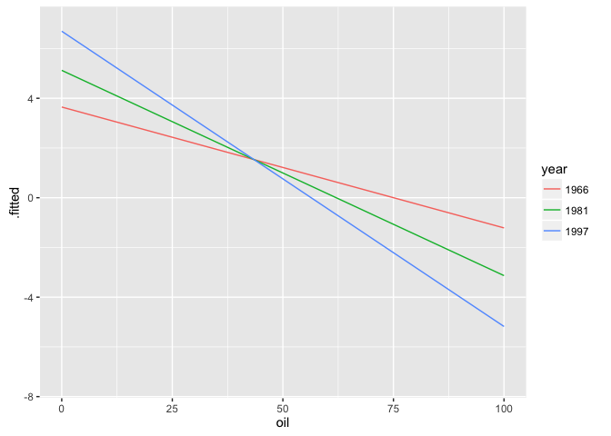

```r
ggplot(pred3, aes(x = oil, y = .fitted, ymin = .fitted - 2 *
  .se.fit, ymax = .fitted + 2 * .se.fit, colour = factor(year))) +
  geom_line() + scale_colour_discrete("year")
```

This could also be visualized with colour and contours

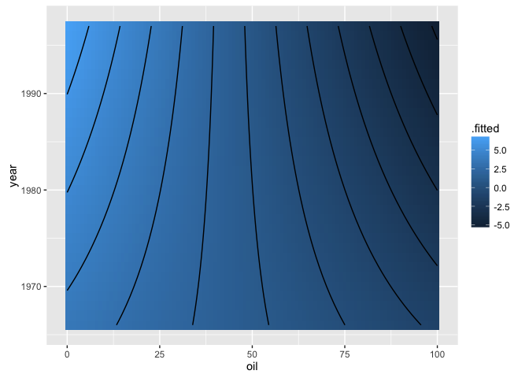

```r
pred3_newdata <- expand.grid(oecd = 0, GDPcap = mean(rossdata$GDPcap),
  year = unique(rossdata$year), oil = seq(0, 100, by = 1))
pred3 <- augment(model3, newdata = pred3_newdata)
ggplot(pred3, aes(x = oil, y = year, fill = .fitted, z = .fitted)) +
  geom_tile() + geom_contour(colour = "black") + scale_colour_discrete("year")
```

**Challenge** Interact `GDPpc` with oil and visualize the interactions.

## First Differences

```r
year_seq <- seq(min(rossdata$year), max(rossdata$year), by = 1)
oil_lo <- mean(rossdata$GDPcap)
oil_hi <- mean(rossdata$GDPcap) + sd(rossdata$GDPcap)
pred3_oil_lo <- predict(model3, newdata = data.frame(year = year_seq,
  GDPcap = mean(rossdata$GDPcap), oil = oil_lo, oecd = 0),
  interval = "confidence")

pred3_oil_hi <- predict(model3, newdata = data.frame(year = year_seq,
  GDPcap = mean(rossdata$GDPcap), oil = oil_hi, oecd = 0),
  interval = "confidence")
```

The first difference is calculated. Note that there are no standard error associated with these differences.

```r
pred3_diff <- data.frame(year = year_seq, diff = pred3_oil_hi[,
  "fit"] - pred3_oil_lo[, "fit"])
head(pred3_diff)
```

```
##   year      diff
## 1 1966 -259.0802
## 2 1967 -271.1370
## 3 1968 -283.1938
## 4 1969 -295.2507
## 5 1970 -307.3075
## 6 1971 -319.3643
```

We could plot these differences over time.

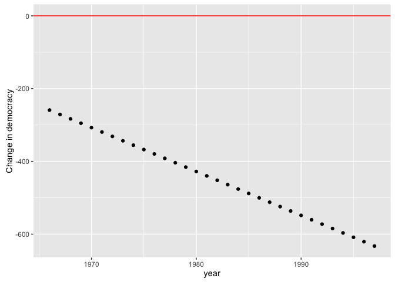

```r
ggplot(pred3_diff, aes(x = year, y = diff)) + geom_point() +
  geom_hline(yintercept = 0, colour = "red") + scale_y_continuous("Change in democracy")
```

# Transformations

What if we suspect the effect of oil is non-linear?

```r
model4 <- lm(regime1 ~ GDPcap + oil + I(oil^2) + oecd, data = rossdata)
summary(model4)
```

```
##
## Call:
## lm(formula = regime1 ~ GDPcap + oil + I(oil^2) + oecd, data = rossdata)
##
## Residuals:
##     Min      1Q  Median      3Q     Max
## -7.6194 -2.7171 -0.1169  2.1843  7.8092
##
## Coefficients:
##               Estimate Std. Error t value Pr(>|t|)
## (Intercept)  4.593e+00  8.301e-02  55.329   <2e-16 ***
## GDPcap       1.878e-04  1.425e-05  13.180   <2e-16 ***
## oil         -1.084e-01  1.213e-02  -8.935   <2e-16 ***
## I(oil^2)     2.691e-04  1.941e-04   1.387    0.166
## oecd         3.171e+00  1.759e-01  18.034   <2e-16 ***
## ---
## Signif. codes:  0 '***' 0.001 '**' 0.01 '*' 0.05 '.' 0.1 ' ' 1
##
## Residual standard error: 2.995 on 2589 degrees of freedom
## Multiple R-squared:  0.4036, Adjusted R-squared:  0.4027
## F-statistic:   438 on 4 and 2589 DF,  p-value: < 2.2e-16
```

```r
model4 <- lm(regime1 ~ GDPcap + oil + I(oil^2) + oecd, data = rossdata)
summary(model4)
```

```
##
## Call:
## lm(formula = regime1 ~ GDPcap + oil + I(oil^2) + oecd, data = rossdata)
##
## Residuals:
##     Min      1Q  Median      3Q     Max
## -7.6194 -2.7171 -0.1169  2.1843  7.8092
##
## Coefficients:
##               Estimate Std. Error t value Pr(>|t|)
## (Intercept)  4.593e+00  8.301e-02  55.329   <2e-16 ***
## GDPcap       1.878e-04  1.425e-05  13.180   <2e-16 ***
## oil         -1.084e-01  1.213e-02  -8.935   <2e-16 ***
## I(oil^2)     2.691e-04  1.941e-04   1.387    0.166
## oecd         3.171e+00  1.759e-01  18.034   <2e-16 ***
## ---
## Signif. codes:  0 '***' 0.001 '**' 0.01 '*' 0.05 '.' 0.1 ' ' 1
##
## Residual standard error: 2.995 on 2589 degrees of freedom
## Multiple R-squared:  0.4036, Adjusted R-squared:  0.4027
## F-statistic:   438 on 4 and 2589 DF,  p-value: < 2.2e-16
```

```r
pred4 <- predict(model4, newdata = data.frame(oil = seq(from = 0.01,
  to = 100, by = 10), GDPcap = mean(rossdata$GDPcap), oecd = 0),
  interval = "confidence")
```

**Challenge:** Transform GDP per capita by log.

**Challenge:** Transform oil by log. What happens? How would you solve it?

Log of 0 is undefined. This is often handled by adding and arbitrary small value to 0’s. In this case we’ll add 0.001. There are better ways to deal with this, but for now…

```r
model5 <- lm(regime1 ~ GDPcap + log(oil_mod) + oecd, data = mutate(rossdata,
  oil_mod = log(oil + 0.001)))
summary(model5)
```

```
##
## Call:
## lm(formula = regime1 ~ GDPcap + log(oil_mod) + oecd, data = mutate(rossdata,
##     oil_mod = log(oil + 0.001)))
##
## Residuals:
##      Min       1Q   Median       3Q      Max
## -10.6337  -2.4525  -0.7552   1.2146   6.5659
##
## Coefficients:
##                Estimate Std. Error t value Pr(>|t|)
## (Intercept)   3.850e+00  1.434e-01  26.847  < 2e-16 ***
## GDPcap        2.708e-05  2.419e-05   1.119    0.263
## log(oil_mod) -7.896e-01  1.018e-01  -7.755 2.42e-14 ***
## oecd          5.420e+00  3.310e-01  16.373  < 2e-16 ***
## ---
## Signif. codes:  0 '***' 0.001 '**' 0.01 '*' 0.05 '.' 0.1 ' ' 1
##
## Residual standard error: 2.976 on 887 degrees of freedom
##   (1703 observations deleted due to missingness)
## Multiple R-squared:  0.4523, Adjusted R-squared:  0.4504
## F-statistic: 244.1 on 3 and 887 DF,  p-value: < 2.2e-16
```

```r
pred5 <- predict(model5, newdata = data.frame(oil_mod = seq(from = 0.01,
  to = 100, by = 10), GDPcap = mean(rossdata$GDPcap), oecd = 0),
  interval = "confidence")
```

# Robust standard errors

We can calculate heteroskedasticity consistent (robust, White) standard errors using the **car** function `hccm`:

The robust standard errors for the coefficients of `model1` are:

```r
sqrt(diag(hccm(model1)))
```

```
##  (Intercept)       GDPcap          oil         oecd         year
## 1.744310e+01 1.710027e-05 4.213601e-03 1.848413e-01 8.813878e-03
```

Are they different than the classical standard errors of those in `model1`?

To use the robust standard errors in a significance test supply the robust variance-covariance matrix to the `coeftest` function from the **lmtest** package:

```r
coeftest(model1, hccm(model1))
```

```
##
## t test of coefficients:
##
##                Estimate  Std. Error  t value  Pr(>|t|)
## (Intercept) -1.7363e+02  1.7443e+01  -9.9542 < 2.2e-16 ***
## GDPcap       6.1766e-05  1.7100e-05   3.6120 0.0003096 ***
## oil         -8.2617e-02  4.2136e-03 -19.6073 < 2.2e-16 ***
## oecd         4.1160e+00  1.8484e-01  22.2676 < 2.2e-16 ***
## year         9.0084e-02  8.8139e-03  10.2207 < 2.2e-16 ***
## ---
## Signif. codes:  0 '***' 0.001 '**' 0.01 '*' 0.05 '.' 0.1 ' ' 1
```

# Post-estimation Diagnostics

Recall the default model,

```r
model1
```

```
##
## Call:
## lm(formula = regime1 ~ GDPcap + oil + oecd + year, data = rossdata)
##
## Coefficients:
## (Intercept)       GDPcap          oil         oecd         year
##  -1.736e+02    6.177e-05   -8.262e-02    4.116e+00    9.008e-02
```

```r
residuals(model1)
fitted(model1)
```

```r
model1_aug <- augment(model1)
```

We can plot the fitted values vs. the outcome variable to look for nonlinearity,

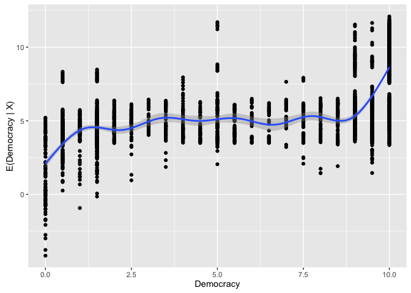

```r
ggplot(model1_aug, aes(x = regime1, y = .fitted)) + geom_point() +
  geom_smooth() + ylab("E(Democracy | X)") + xlab("Democracy")
```

or the residuals vs. the fitted values to look for heteroskedasticity

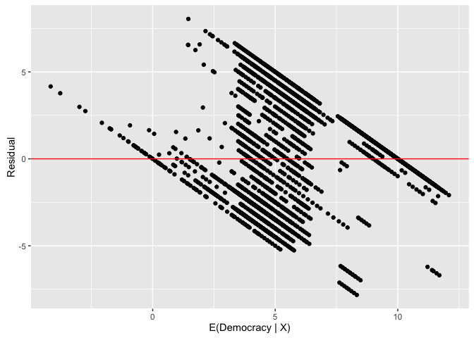

```r
ggplot(model1_aug, aes(x = .fitted, y = .resid)) + geom_point() +
  geom_hline(yintercept = 0, colour = "red") + ylab("Residual") +
  xlab("E(Democracy | X)")
```

**Challenge:** What accounts for the unusual patterns? *hint:* What values can Democracy take?

It is obvious in this case, but plotting the sqrt of the absolute value of the errors can make it more clear

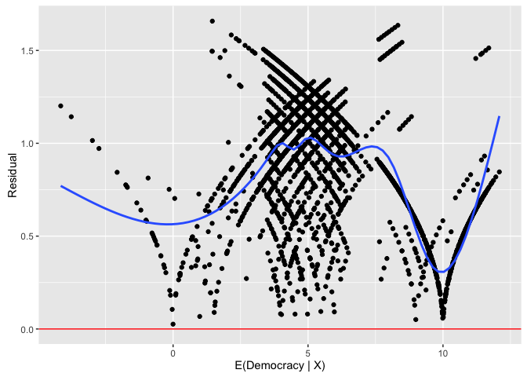

```r
ggplot(model1_aug, aes(x = .fitted, y = sqrt(abs(.std.resid)))) +
  geom_point() + geom_hline(yintercept = 0, colour = "red") +
  geom_smooth(se = FALSE) + ylab("Residual") + xlab("E(Democracy | X)")
```

**Challenge:** Plot residuals against each independent variable, and the fitted values. Is there evidence of heteroskedasticity or nonlinearity?

What about the normality of errors?

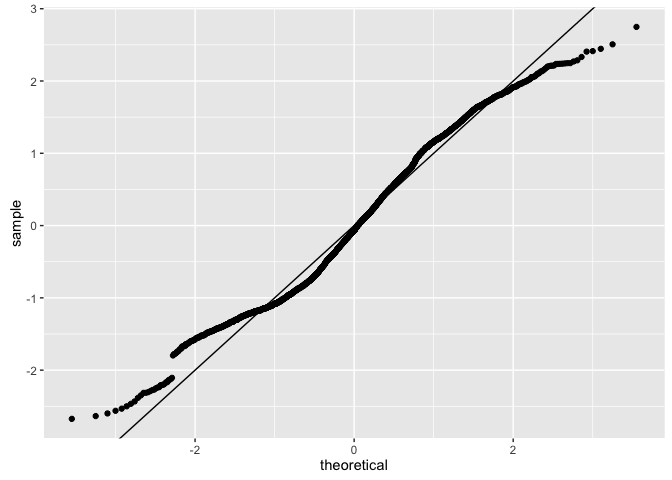

```r
ggplot(model1_aug, aes(sample = .std.resid)) + stat_qq() + geom_abline(slope = 1)
```

For more advanced residual plots see **car** functions:

- `avPlots`: added variable plot
- `ceresPlots`, `crPlots`: Component + residual (partial residual) plots
- `residualPlots`

Also try using `plot` on an `lm` object:

```r
plot(model1)
```

# Writing to a file

You can use the function `write.csv` to save data to a csv file.

Try it!

You can use the function `save` to a save R objects to a native R file format. Save these to files ending in `.RData`. You can then load the objects back into your workspace using `load()`. tor reproducibility and transparancy it is better to save your data in language agnostic file formats, such as csvs, rather than language specific formats like `.RData` (R) or `.dta` (Stata).

# A quick introduction to functions

This is an example of a really stupid R function that adds two to each variable.

```r
add2 <- function(x) {
  x + 2
}
```

Try it …

Functions are a way of encapsulating and reusing code. It takes a set of inputs (arguments), does some computation in its body, and then returns the result.

A *slightly* more realistic function is one that calculates the difference between the min and maximum value of a vector, i.e. the range:

```r
diff_min_max <- function(x) {
  max(x) - min(x)
}
```

IRL, you would you the `range` function, but this is for pedagogy.

1. Write a function that calculates the difference between the 97.5 and 2.5 percentiles.
2. Now add a parameter that lets you set the values of the quantiles to use in the difference. This means that instead of 97.5 and 2.5, you can use any values.

For meore on writing functions see: http://www.ats.ucla.edu/stat/r/library/intro_function.htm

# Sources

- Oil data from : Ross 2001.
- http://staff.washington.edu/csjohns/503/lab5.r
- http://staff.washington.edu/csjohns/503/lab6.r

This work is licensed under a [Creative Commons Attribution-NonCommercial-ShareAlike 4.0 International License](http://creativecommons.org/licenses/by-nc-sa/4.0/). R code is licensed under a [BSD 2-clause](http://www.r-project.org/Licenses/BSD_2_clause) license.